# What a teacher actually knows

Week 2 · Chapter 1 · Professional Teaching Knowledge

Study · Week 2

Read Chapter 1 of the textbook (Eggen & Kauchak, 2025) before you read this brief. The brief replaces the lecture video: it identifies what matters in the chapter and asks you to use it before Tuesday.

About 20 minutes: reading, one place you stop and write, and 8 quick checks.

Pair this with **the Walkthrough**, a 13-minute video in which I analyze the one note in the folder that seems to have nothing wrong with it.

## The claim you already believe

**Many people believe that good teachers are people who know their subject and are good with people.**

Almost everyone arrives with a version of this belief, and because it is half true, it survives contact with many classrooms.

Consider a test of the belief. Two people teach the same lesson on fractions. Both know the mathematics thoroughly, and both are warm, funny and well liked. One class understands the lesson and the other does not.

The belief cannot explain why the two classes learned differently, because it gives both teachers the same rating.

## Four kinds of professional knowledge

Chapter 1’s central claim is that professional teaching knowledge has at least four kinds. Because they are separable, a teacher can be strong in one and have very little of another.

Content knowledge: the subject itself, such as mathematics, ELA, science, music or PE. You cannot teach what you do not know. This knowledge is necessary, but it is nowhere near sufficient.

Pedagogical content knowledge: how to make *this particular idea* learnable. A teacher with this knowledge knows how to teach fractions: which representation to use, which example to show first, and which misconception to expect.

Knowledge of learners: who your students are, including their development, context and needs. Units 1 and 4 address this knowledge.

Knowledge of learning: how people acquire and retain anything at all. It includes memory, motivation and transfer, and Units 2 and 3 address it. Your 13,000 hours as a student taught you least about this kind, because students cannot see it from a desk.

True or false?

A teacher who knows her subject deeply will be able to teach it well.

Not quite Content knowledge is necessary and nowhere near sufficient. Both fraction teachers know the mathematics thoroughly.

Right Knowing the subject is one of four kinds of knowledge. The chapter argues that the others are separate.

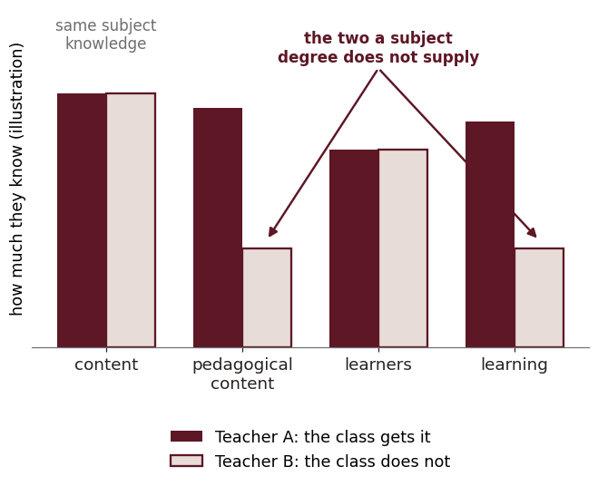

Two fraction teachers with the same subject knowledge. The difference sits in the two kinds a subject degree does not supply.

Your two fraction teachers differ in **pedagogical content knowledge** and **knowledge of learning**. A subject degree does not supply these two kinds, and a friendly personality does not replace them.

Commit first

A student says *“I don’t get it”* about something you just explained clearly and correctly.

**Which of the four kinds of knowledge best explains the problem, and what is your next move?** Write two or three sentences before you read on, and give a reason for your choice.

The most common answer is *knowledge of learners*, because teachers conclude that they need to know more about this student. The answer is reasonable, but the problem is usually somewhere else.

**The most likely problem is pedagogical content knowledge.** “Clearly and correctly” describes the explanation, but it does not tell us what happened in the student’s head. Even a correct explanation fails when it begins from an idea the student does not have.

Repeating the explanation more slowly or more kindly will not solve the problem. The teacher needs to find out **what the student thinks is true** and start from there, which is a different professional act, and one that teachers can learn.

Content knowledge alone does not allow you to make that move, and this is the chapter’s main argument.

Check yourself

A music teacher knows that beginners always clap one rhythm wrong, so she starts with a clapping game that exposes the mistake. Which knowledge is this?

More than the music Knowing the rhythm is content knowledge. Knowing which part beginners get wrong, and how to expose it, requires more.

Yes She anticipates a predictable error in a specific idea and chooses a representation to address it. That is pedagogical content knowledge (PCK).

Too general She is not responding to particular students. Every beginner makes this mistake.

Too general Knowledge of learning covers how anyone learns anything. This is specific to one rhythm.

## Self-efficacy differs across tasks

**Self-efficacy** is your belief that you can successfully do a specific task (Bandura, 1977). It is narrower than self-esteem or general confidence, because it refers to *this task, this context.*

Self-efficacy predicts what teachers actually attempt, including persistence with a struggling student, willingness to try an unfamiliar method, and how long they continue before they conclude that something cannot be done. You will study it again in Unit 3, when a *student’s* self-efficacy is low.

True or false?

A teacher who feels sure she can explain her subject will also feel sure she can manage a classroom.

Not quite Self-efficacy is domain-specific. Highly efficacious about explaining and near zero about managing a room is common.

Right Explaining and managing a room are different tasks, and confidence in one says little about the other.

**Self-efficacy is domain-specific, so it can be high in one domain and low in another.** You can be highly efficacious about explaining your subject and near zero about managing a room. If we average those beliefs into “confidence,” we lose the only useful information.

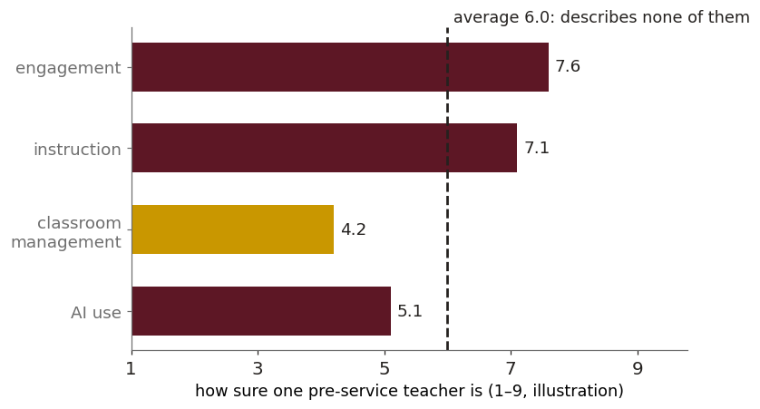

One pre-service teacher’s self-efficacy across four domains. The average describes none of them.

Teaching knowledge also differs across domains. This week’s instrument is the [TPACK self-assessment](https://faaparrama.github.io/Tpack/), which measures your knowledge of technology, pedagogy and content, and of the places where they combine (Mishra & Koehler, 2006). **You will report and interpret your own scores in Part 1 of the Reflection.** Expect the domains to disagree, because most new teachers score high on technology and lower on combining all three. That disagreement is the finding you will interpret.

## Twenty principles and five questions

The APA’s *Top 20 Principles for PreK–12 Teaching and Learning* (American Psychological Association, 2015) is useful and slightly overwhelming, because twenty numbered principles are difficult to remember. The principles are related to each other, and we can group them into five questions:

| The question | Principles about |
| --- | --- |
| **What does the learner already believe?** | prior knowledge · misconceptions · developmental stage |
| **What makes them engage?** | mindset · intrinsic motivation · mastery goals · expectations · goal setting |
| **What makes it stick?** | practice · transfer with context · self-regulation · feedback |
| **What does the room have to be like?** | social context · relationships · emotional safety · behaviour and norms |
| **How do you know any of it worked?** | formative and summative assessment · fairness · valid interpretation |

Those five questions are the four units of this course, plus assessment, which runs through all of them. The principles work as a checklist, and the theory behind them tells you *which one applies right now.*

Check yourself

A teacher notices her students forget fractions over the summer, so she plans short spaced reviews in September. Which of the five questions is she answering?

Close neighbor She knows they forgot. The plan is about holding on to it.

Not about engagement Nothing in the plan is about motivation or goals.

Yes Her plan uses practice, spacing and retention, which belong to the principles about making learning stick.

Not yet Assessment would come later, to check whether the reviews worked.

An expert knows which item applies in a situation, whereas a novice may only have the list. Your capstone is graded on this difference.

True or false?

Memorizing the twenty principles is what separates expert teachers from novices.

Not quite Novices can hold the list. Experts know **which principle applies right now**, and that takes the theory underneath.

Right Anyone can have the list. Expertise is knowing which item applies.

## AI and professional judgment

AI is already part of teaching. The question worth your time is **what it can and cannot substitute for**, and the four kinds of knowledge help us answer it.

|  | AI is genuinely strong | AI is weak or unreliable |
| --- | --- | --- |
| **Content** | recall, definitions, worked examples, drafts | current, local, or specialised material; confident wrong answers |
| **Pedagogical content** | generating alternative representations fast | knowing which one *this* class needs |
| **Learners** | — | it has never met your students |
| **Learning** | naming a principle on request | judging which principle governs the case in front of you |

**AI ≠ professional judgment.** AI is very good at the tasks in the first column, but it is structurally unable to do those in the second, because they require knowing your students.

True or false?

Because a chatbot can produce many representations of an idea quickly, it can choose the one your class needs.

Not quite Generating representations is its strength. Choosing one for *this* class needs knowledge of the learners, and it has never met them.

Right It generates fast and cannot choose for a room it has never seen.

This week’s **Friction Move** lets you test that claim for yourself. If you do it, run it before Tuesday.

## Check yourself

Check yourself

A teacher knows the causes of the Civil War thoroughly, and her students consistently misunderstand the same point about states’ rights. Which knowledge is most directly implicated?

Not quite The question states that she knows the history thoroughly. This is the most common wrong answer because content knowledge is the most visible kind, which is why the chapter separates the four.

Not the closest fit Knowledge of learners would matter if *particular* students struggled for particular reasons. Here the whole class misses the *same point*, so the pattern suggests a problem in how the idea is being taught.

Yes A predictable, recurring misconception about a specific topic is the signature of a pedagogical content knowledge gap. Knowing the history is different from knowing which representation of it fails, and how.

Close, but too general Knowledge of learning covers how people acquire and retain anything. This problem is specific to *this idea in this subject*, which is the narrower category.

Check yourself

Which is the best evidence that a teacher’s self-efficacy is high for classroom management specifically?

Wrong construct That is job satisfaction. Self-efficacy is a belief about *capability on a specific task*, so you can love teaching and believe you are bad at managing a room.

Yes Persistence after failure is the behavioral signature of self-efficacy, and it is domain-specific, because this example is about management and says nothing about instruction. In Unit 3 you will see the same signature *absent* in a student, and it will look like laziness.

That is an outcome, not a belief Scores are affected by a great deal that she does not control. Self-efficacy is what she believes she can do, which is why researchers measure it by self-report and do not infer it from results.

Experience is not efficacy Fifteen years of a strategy that does not work can lower self-efficacy. Time on the job predicts it weakly and sometimes negatively.

Bring to Tuesday **Two or three questions** that the chapter did not answer and that you could not settle by reading it again.

**One example from your own subject** of pedagogical content knowledge: a specific idea in your field that is predictably hard, with an explanation of what makes it hard.

The retrieval check closes **Tuesday at noon**. I read the results before class, and Tuesday begins with the questions that most students missed.

## Sources

American Psychological Association, Coalition for Psychology in Schools and Education. (2015). *Top 20 principles from psychology for preK–12 teaching and learning.* American Psychological Association.

Bandura, A. (1977). Self-efficacy: Toward a unifying theory of behavioral change. *Psychological Review, 84*(2), 191–215.

Eggen, P. D., & Kauchak, D. P. (2025). *Using educational psychology in teaching* (12th ed.). Pearson. **This week: Chapter 1.**

Mishra, P., & Koehler, M. J. (2006). Technological pedagogical content knowledge: A framework for teacher knowledge. *Teachers College Record, 108*(6), 1017–1054.

Shulman, L. S. (1986). Those who understand: Knowledge growth in teaching. *Educational Researcher, 15*(2), 4–14.